# Introduction and Summary

Description of Publicly Available Methylation Datasets

| GEO ID | Melanoma Samples | Nevus | Notes |
| --- | --- | --- | --- |
| GSE120878 | 89 | 73 | FFPE Biospies |
| GSE122909 | 11 | 0 | 11 Melanomas + 9 Cultured Melanocytes |
| GSE86355 | 33 + 28 (Primary and Metastatic) | 14 | Could potentially be used to increase model dataset |
| TCGA-SKCM | 473 (105 Primary, 367 Metastatic) |  |  |

Additional Gene Expression Data Generated on Melanoma vs Nevus Samples

| GEO ID | Samples | Array Type |
| --- | --- | --- |
| GSE12391 | 114 | Agilent Microarray |
| GSE8401 | 83 | Affymetrix Microarray |
| GSE7553 | 87 | Affymetrix Microarray |

```r
library(minfi)
library(tidyverse)
library(lumi)
library(DMRcate)
library(GEOquery)


theme_set(theme_light() + theme(text = element_text(face = "bold"),
    panel.grid = element_blank()))
```

```r
utils <- list.files("~/Documents/MitraStuff/", pattern = ".R",
    full.names = T)
lapply(utils[-grep(".Rmd", utils)], source)

# for i in $(ls *Grn*); do mv $i $(basename $i
# .idat.gz)_Grn.idat.gz ;done for i in $(ls *Red*); do mv
# $i $(basename $i .idat.gz)_Red.idat.gz ;done for file in
# $(ls *Grn*); do mv '${file}' '${file/Grn_/}'; done for
# file in $(ls *Red*); do mv '${file}' '${file/Red_/}';
# done for i in $(ls *Red*); do mv $i $(basename $i
# .idat.gz)_Red.idat.gz ;done
# GSM3417694_melanocytic_Red_1391.idat.gz >>>
# GSM3417694_melanocytic_Red_1391_Red.idat.gz

# for file in $(ls *Red*); do mv '${file}' '${file/Red_/}';
# done GSM3417694_melanocytic_Red_1391_Red.idat.gz >>>
# GSM3417694_melanocytic_1391_Red.idat.gz
```

```r
pdata <- getGEO("GSE120878")[[1]] %>%
    pData

pdata$file_link <- pdata$supplementary_file
pdata$file_link[grep("Grn", pdata$file_link)] <- gsub(".*\\/",
    "", pdata$file_link[grep("Grn", pdata$file_link)]) %>%
    gsub("Grn_", "", .) %>%
    gsub(".idat.gz", "", .)

pdata$Basename <- paste0("./GSE120878_RAW/", pdata$file_link)
pdata$Type <- if_else(pdata$`tissue:ch1` == "primary invasive melanoma",
    "PrimaryMelanoma", "Nevus")

idats <- read.metharray.exp(targets = pdata, verbose = T)
# idats_backup <- idats idats <- idats_backup
anno <- getAnnotation(idats) %>%
    as.data.frame()
```

```r
pvals <- detectionP(idats)


filter.p <- function(x, detected.p.vals) {
    detected.p.vals <- detected.p.vals[match(featureNames(x),
        rownames(detected.p.vals)), ]
    filtered.01 <- rowSums(detected.p.vals < 0.01) == ncol(x)
    cat("A total of", sum(filtered.01 == FALSE), "low quality probes were removed")
    x <- x[filtered.01, ]
}

idats <- preprocessNoob(idats)
idats <- filter.p(idats, pvals)


remove.snps <- function(x, dist = 2, maf = 0.05, xhyb = T, xy = F) {
    a <- nrow(x)
    x <- DMRcate::rmSNPandCH(x, dist = dist, mafcut = maf, rmcrosshyb = xhyb,
        rmXY = xy)
    b <- nrow(x)
    cat("A total of", sum(a - b), "probes removed with distance from CpG of",
        dist, "and a minor allele freq of", maf)
    return(x)
}

library(ENmix)
betas <- rcp(idats)
M <- lumi::beta2m(betas + 0.001)


betas <- remove.snps(betas, dist = 2, maf = 0.05, xhyb = T, xy = T)
M <- remove.snps(M, dist = 2, maf = 0.05, xhyb = T, xy = T)
```

# Exploratory Data Analysis

## Unnormalised Beta Value Distribution

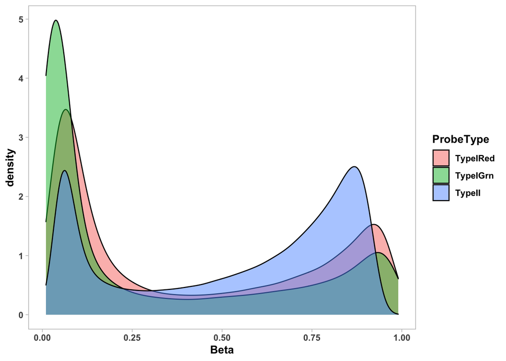

Unnormalised distribution of beta values

```r
probe_type <- data.frame(CpG = anno$Name, ProbeType = as.factor(paste0("Type",
    anno$Type, anno$Color)))

raw <- getBeta(idats) %>%
    rowMeans() %>%
    as.data.frame() %>%
    `colnames<-`("Beta") %>%
    rownames_to_column(var = "CpG") %>%
    inner_join(probe_type)

raw$ProbeType <- factor(raw$ProbeType, levels = c("TypeIRed",
    "TypeIGrn", "TypeII"))

ggplot(raw, aes(x = Beta), col = "black") + geom_density(aes(fill = ProbeType),
    alpha = 0.5)
```

## Normalised Beta Value Distribution

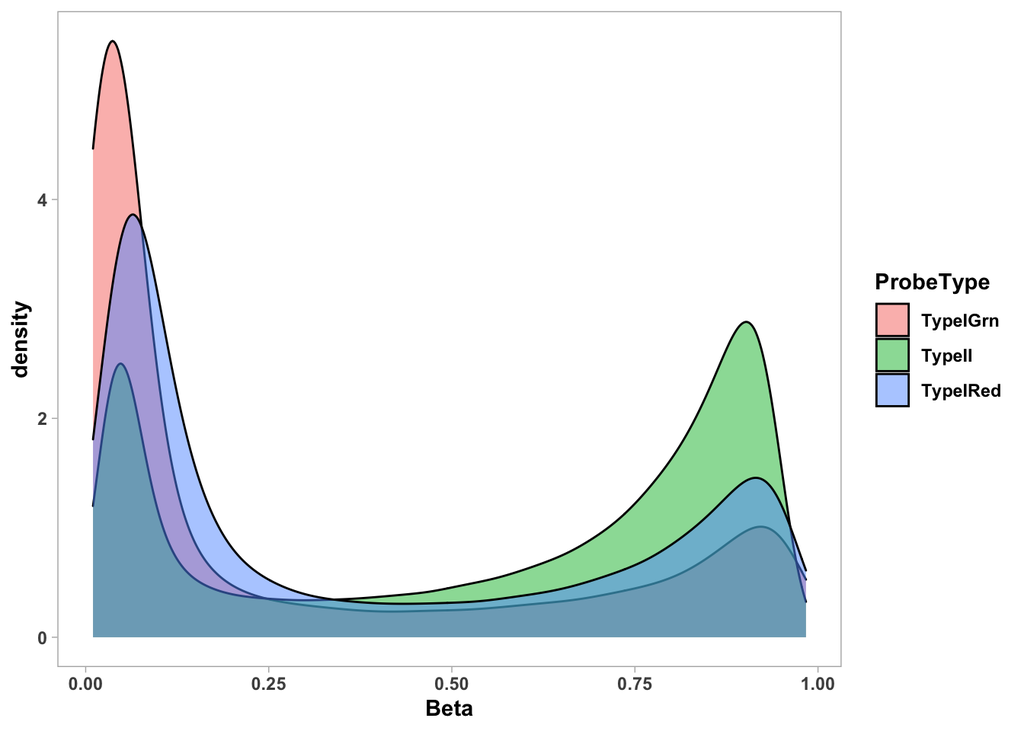

Normalised distribution of beta values following Noob dye bias correction and regression of correlated probes (RCP) normalisation

```r
rcp <- betas %>%
    rowMeans() %>%
    as.data.frame() %>%
    `colnames<-`("Beta") %>%
    rownames_to_column(var = "CpG") %>%
    inner_join(probe_type)


ggplot(rcp, aes(x = Beta), col = "black") + geom_density(aes(fill = ProbeType),
    alpha = 0.5)
```

## Preprocessing and QC of 450k Probes

Number of CpGs filtered at each processing step. The detection PValue metric describes the confidence in the signal from a probe being real dependent on whether its background intensity was above that of the control (non-human/non-targeting oligos) on the array. The number of probes that failed based on their detection PValue being > 0.01 is quite substanial. However, these arrays were hybridised from DNA extracted from FFPE biopsies which may affect the quality/purity of the DNA. The remaining probes all hybridised with sufficient confidence.

| Processing Steps | CpGs |
| --- | --- |
| Detection PValue | 109,460 |
| X&Y, SNPs | 40,042 |

## Conversion of Beta Values to M Values for Downstream Statistical Modelling

Conversion of Beta to M values

Beta values were converted to M values as follows;

$$\Large{M_i = }
\Large{log2\bigg(\frac{Beta_i}{1-Beta_i}\bigg)}$$

Distributions of Beta and M Values can be seen below.

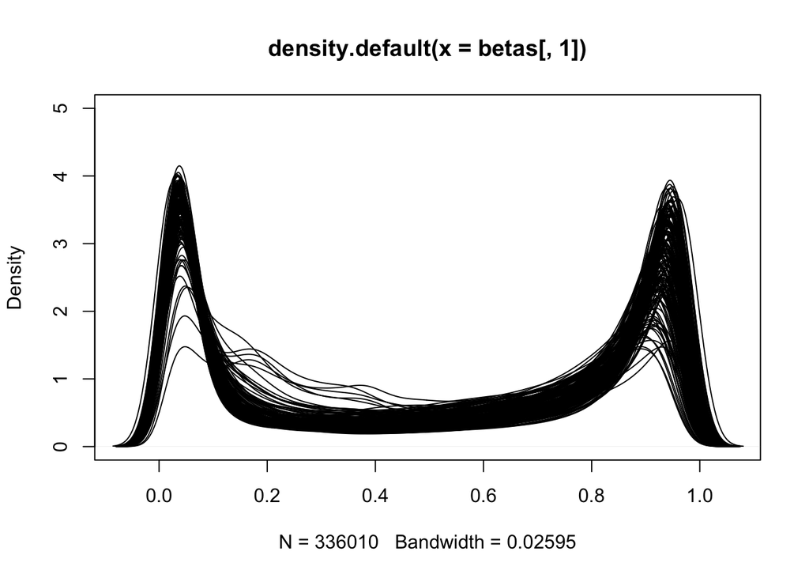

Density plot of distribution of Beta Values across all samples

```r
plot(density(betas[, 1]), ylim = c(0, 5))
for (i in 2:ncol(betas)) {
    lines(density(betas[, i]))
}
```

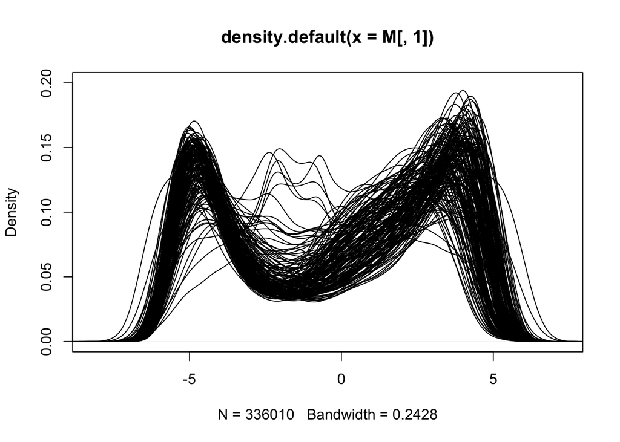

Density plot of distribution of M Values across all samples

```r
plot(density(M[, 1]), ylim = c(0, 0.2))
for (i in 2:ncol(M)) {
    lines(density(M[, i]))
}
```

# Principal Component Analysis Shows Good Separation Between Melanoma and Nevus Samples

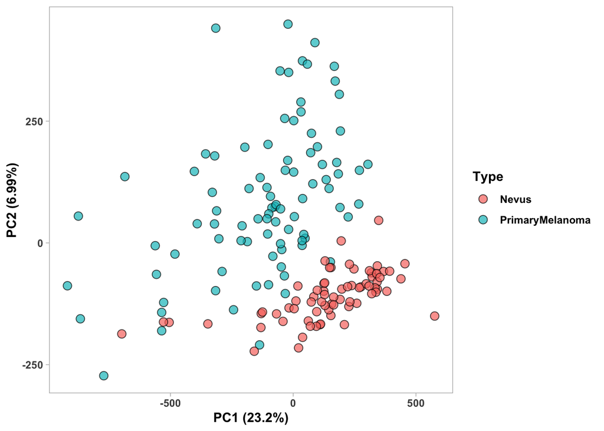

Scores plot from principal component analysis of M values from the 336,010 CpG probes that remained after filtering and preprocessing. Points (samples) are coloured by the variable Type which describes whether the DNA was extracted from a Primary Melanoma or a Nevus sample. Clear separation can be observed between the sample types across the first two principal components indicating that Nevus and Primary Melanoma FFPE samples have distinct epigenome-wide methylation differences.

```r
full_pca <- plot_pca_alpha(M, phenotype = pdata, scale = T, variable = "Type")
```

# A Preliminary Model To Discriminate Between Melanoma and Nevus Samples

## Building a preliminary model of Melanoma vs Nevus

```r
set.seed(123)
inTrain <- createDataPartition(pdata$Type, p = 0.6, list = F)

train_mel <- t(M[, inTrain])
test_mel <- t(M[, -inTrain])

# train_mel <- train_mel[rowVars(train_mel) > 0.01,]

train_pheno <- pdata[inTrain, ]
test_pheno <- pdata[-inTrain, ]

opt_alpha <- data.frame(Alpha = seq(0, 1, length.out = 3), Error = 0)
seq_alphas <- seq(0, 1, length.out = 3)



set.seed(123)
foldid <- sample(1:10, size = length(train_pheno$Type), replace = TRUE)
for (i in 1:3) {
    opt_lambda <- cv.glmnet(train_mel, as.factor(train_pheno$Type),
        type.measure = "class", nfolds = 10, alpha = seq_alphas[i],
        family = "binomial", parallel = F, foldid = foldid)
    opt_alpha$Error[i] <- opt_lambda$cvm[opt_lambda$lambda ==
        opt_lambda$lambda.1se]
    print(i)
}

opt_lambda_final <- cv.glmnet(train_mel, as.factor(train_pheno$Type),
    type.measure = "class", nfolds = 10, alpha = 0.5, family = "binomial",
    parallel = F, foldid = foldid)
```

## Cross Validated Error of Various Regularised Modelling Approaches

Out of bag cross validated error for different values of alpha in the regularised linear models

| Alpha | Cross-Validated Error |
| --- | --- |
| 0 (Ridge) | 0.031 |
| 0.5 (Elastic Net) | 0.010 |
| 1 (Lasso) | 0.010 |

## Identification of a 104 CpG Signature To Predict Melanoma In Skin Biopsies

```r
glm_mod <- glmnet(train_mel, as.factor(train_pheno$Type), type.measure = "class",
    alpha = 0.5, family = "binomial")

elas_glm_coefficients <- extract_glm_coefficients(glm_mod, opt_lambda = opt_lambda_final$lambda.1se)
elas_glm_coefficients <- elas_glm_coefficients %>%
    left_join(anno, by = c(name = "Name"))
```

## Principal Component Analysis Of The 104 CpG Signature

Using the 104 CpGs selected there is clear separation across the entire dataset and also the independent test dataset.

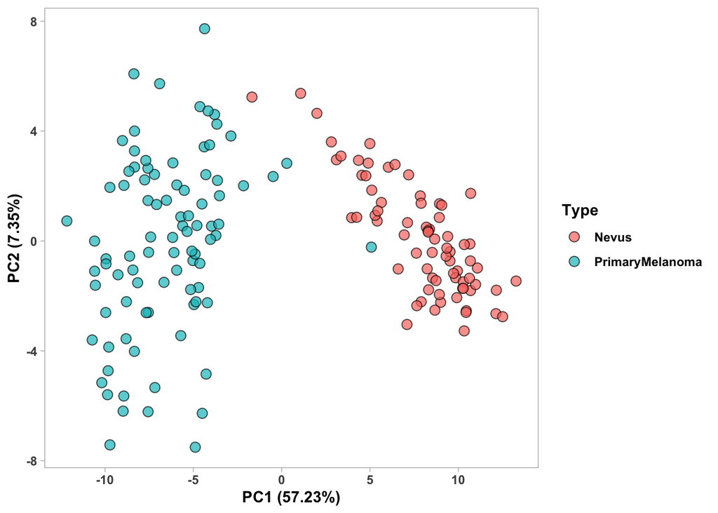

Scores plot from a principal component analysis based on the 104 coefficients selected by the elastic net model on the full GSE120878 dataset, samples are coloured by Origin.

```r
glm_pca <- plot_pca_alpha(M[rownames(M) %in% elas_glm_coefficients$name,
    ], phenotype = pdata, scale = T, variable = "Type")
```

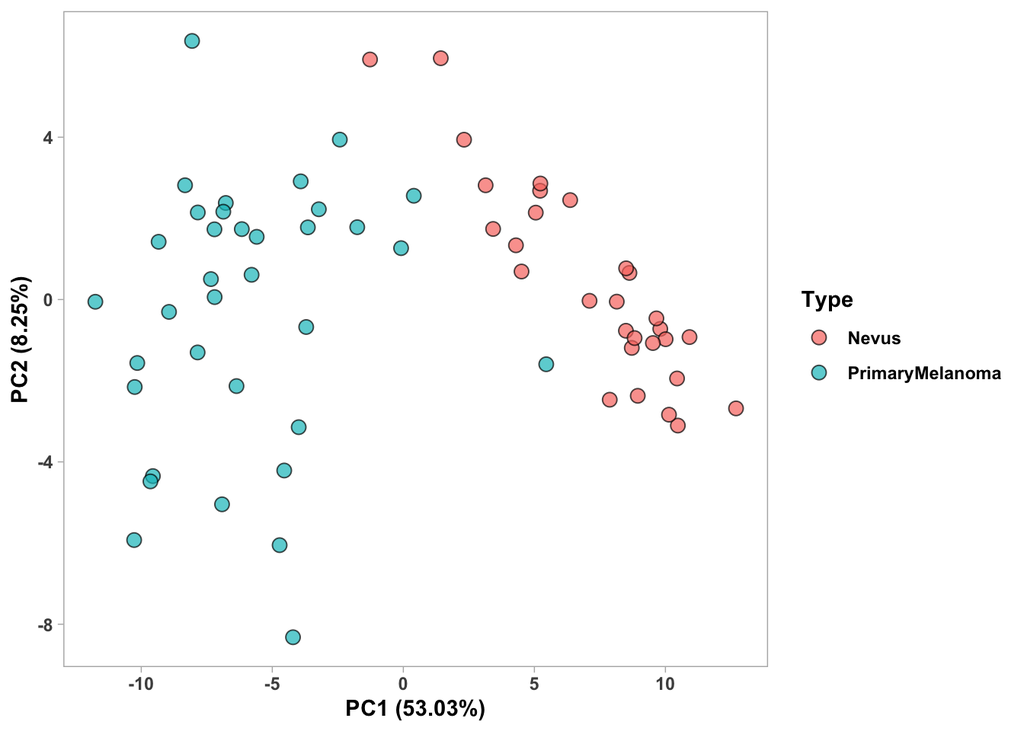

Scores plot from a principal component analysis based on the 104 coefficients selected by the elastic net model on the independent test dataset partitioned from GSE120878, samples are coloured by Origin.

```r
glm_pca_test <- plot_pca_alpha(t(test_mel[, colnames(test_mel) %in%
    elas_glm_coefficients$name]), phenotype = test_pheno, scale = T,
    variable = "Type")
```

## Independent Test Set Predictions

```r
glm_preds <- predict(glm_mod, test_mel, s = opt_lambda_final$lambda.min,
    type = "link")

glm_preds_class <- predict(glm_mod, test_mel, s = opt_lambda_final$lambda.min,
    type = "class")

glm_preds_resp <- predict(glm_mod, test_mel, s = opt_lambda_final$lambda.min,
    type = "response")

glm_preds_class <- data.frame(SampleID = rownames(test_mel),
    Predictions = if_else(glm_preds_class == "PrimaryMelanoma",
        "Melanoma", "Nevus"), Link = as.numeric(glm_preds[, 1]),
    Response = as.numeric(glm_preds_resp[, 1]), Labels = test_pheno$Type)
```

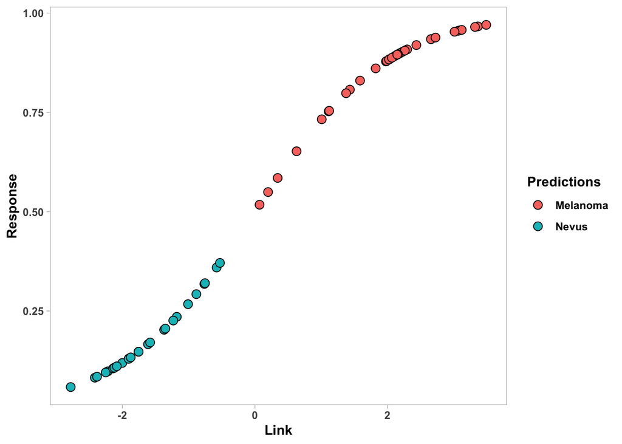

Sanity check of the classification attributed between link and response

```r
ggplot(glm_preds_class, aes(x = Link, y = Response, fill = Predictions)) +
    geom_point(pch = 21, size = 3)
```

## Recievier Operating Curve Of Model Performance On Independent Test Data

```r
my_roc <- function(labels, scores) {
    labels <- labels[order(scores, decreasing = TRUE)]
    data.frame(TPR = cumsum(labels)/sum(labels), FPR = cumsum(!labels)/sum(!labels),
        labels)
}

simp_roc <- my_roc(if_else(glm_preds_class$Labels == "PrimaryMelanoma",
    1, 0), glm_preds_class$Link)
simp_roc$`1 - FDR` <- 1 - simp_roc$FPR
colnames(simp_roc) <- c("Sensitivity", "FPR", "Labels", "Specificity")
```

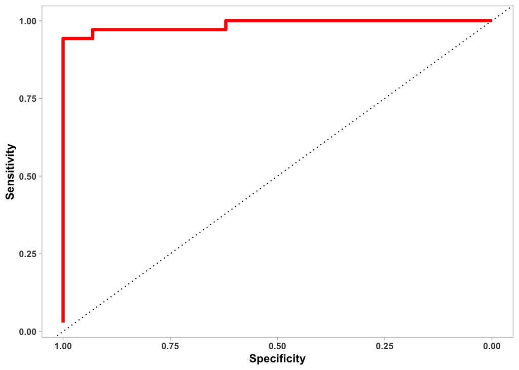

ROC curve of independent test set predictions using the 104 CpG signature

```r
ggplot(simp_roc, aes_string(y = "Sensitivity", x = "Specificity")) +
    geom_line(size = 1.5, col = "red", lty = 1) + scale_x_reverse() +
    geom_abline(intercept = 1, lty = 3)
```

## Additional Metrics Of Model Performance On Independent Test Data

```r
library(caret)
glm_cm <- confusionMatrix(as.factor(glm_preds_class$Predictions),
    as.factor(if_else(glm_preds_class$Labels == "Nevus", "Nevus",
        "Melanoma")))

glm_cm <- glm_cm$byClass %>%
    as.data.frame() %>%
    rownames_to_column(var = "Metric") %>%
    `colnames<-`(c("Metric", "Score"))
```

```r
knitr::kable(glm_cm, caption = "Scores for various metrics from the 104 CpG Melanoma classification signature on independent test data.")
```

Scores for various metrics from the 104 CpG Melanoma classification signature on independent test data.

| Metric | Score |
| --- | --- |
| Sensitivity | 0.9714286 |
| Specificity | 0.9310345 |
| Pos Pred Value | 0.9444444 |
| Neg Pred Value | 0.9642857 |
| Precision | 0.9444444 |
| Recall | 0.9714286 |
| F1 | 0.9577465 |
| Prevalence | 0.5468750 |
| Detection Rate | 0.5312500 |
| Detection Prevalence | 0.5625000 |
| Balanced Accuracy | 0.9512315 |

## Heatmap and Hierachical Clustering of the 104 CpGs On Indepenent Test Data

We can observe good distance based clustering of the Melanoma vs Nevus samples in the independent test set using the 104 CpG signature. Interestingly, we can see that the large majority of CpGs that are hypermethylated in Melanoma vs Nevus samples are found within CpG islands.

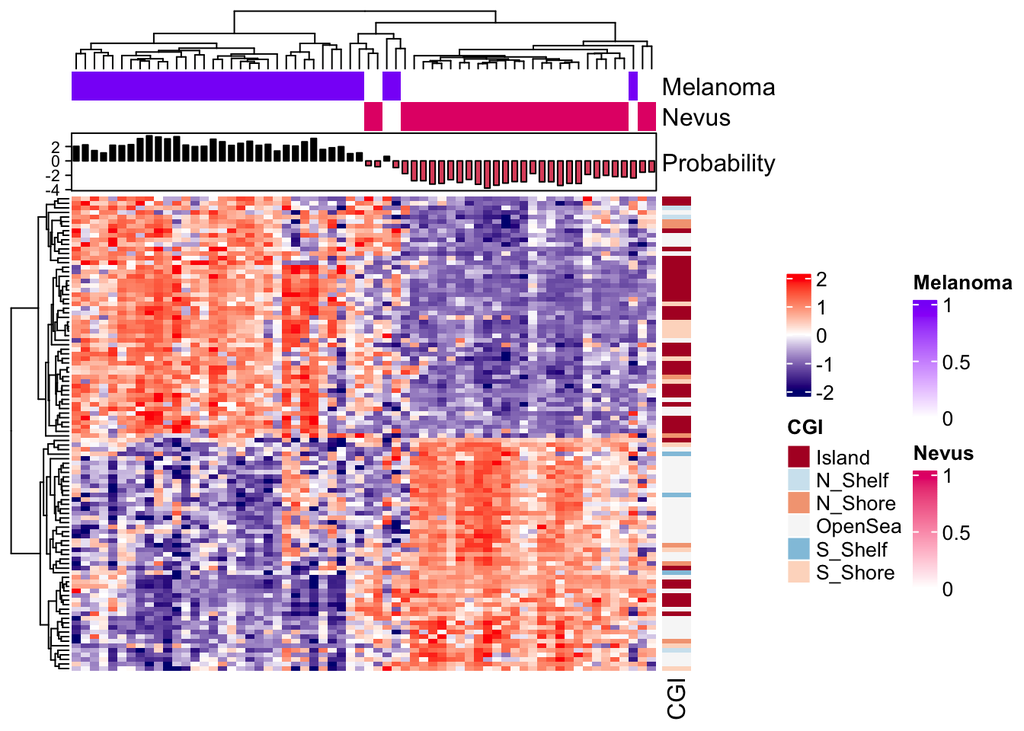

Heatmap of the CpGs selected from the Elastic Net Regression model on the independent test dataset. The heatmap is generated on scaled M values. Probability refers to a transformed probability from the model predictions of a sample being Melanoma or Nevus. The probability was conditionally transformed so that its center was 0 and negative numbers were indiciative of prediction of Nevus and positive values a prediction of Melanoma

```r
library(ComplexHeatmap)
library(circlize)
library(RColorBrewer)
p_anno_test <- data.frame(Nevus = if_else(test_pheno$Type ==
    "Nevus", 1, 0), Melanoma = if_else(test_pheno$Type == "PrimaryMelanoma",
    1, 0), Probability = as.numeric(glm_preds[, 1]), row.names = rownames(test_mel))

ha <- HeatmapAnnotation(Melanoma = if_else(test_pheno$Type ==
    "PrimaryMelanoma", 1, 0), Nevus = if_else(test_pheno$Type ==
    "Nevus", 1, 0), Probability = anno_barplot(if_else(p_anno_test$Probability <
    0.5, p_anno_test$Probability - 1, p_anno_test$Probability),
    baseline = 0, gp = gpar(fill = if_else(p_anno_test$Probability >
        0.5, 1, 2))))

cols1 <- colorRamp2(c(-2, 0, 2), colors = c("navy", "white",
    "red"))

# scale_test <-
# scale(lumi::m2beta(test_mel[,colnames(test_mel) %in%
# elas_glm_coefficients$name]), scale =T, center=T)
scale_test <- scale(test_mel[, colnames(test_mel) %in% elas_glm_coefficients$name],
    scale = T, center = T)

glm_cpg_info <- elas_glm_coefficients[match(colnames(scale_test),
    elas_glm_coefficients$name), ]
glm_cpg_info$CGI <- gsub(";.*", "", glm_cpg_info$Relation_to_Island)

cgi_cols <- brewer.pal(11, "RdBu")
cgi_cols <- cgi_cols[c(2, 4, 5, 7, 8, 6)]
names(cgi_cols) <- c("Island", "N_Shore", "S_Shore", "N_Shelf",
    "S_Shelf", "OpenSea")
ra <- rowAnnotation(CGI = glm_cpg_info$CGI, col = list(CGI = cgi_cols))

Heatmap(t(scale_test), cluster_rows = T, cluster_columns = T,
    clustering_distance_rows = "spearman", clustering_distance_columns = "spearman",
    show_row_names = F, show_column_names = F, top_annotation = ha,
    col = cols1, name = " ", split = c(), right_annotation = ra)
```

# Attempting to Explore the Biology

## Exploring potential pathways for the CpGs within, or closely related to the model.

The lambda regularisation parameters for elastic net are depicted at the end of the formula here. As mentioned above, its quadratic term helps it improve on the sparsity Lasso introduces (which drops colinear variables). However, it still contains a linear combination of lasso and ridge regression penalties which force variable selection in high dimensional settings. Here we work backwards to obtain all CpGs that show high correlations (absolutely pearson correlation > 0.8) with the selected CpGs in the model to obtain a set in which to explore potential biology, rather than serve solely as biomarkers. This identified set is mainly of interest for enrichment based approaches.

$$\normalsize{\sum_{i=1}^{n}\left(y_i-\beta_0-
\sum_{j=1}^{p}\beta_j x_{ij} \right)^2} \LARGE{+
\lambda_1\sum_{j=1}^{p}\beta^2_j +
\lambda_2\sum_{j=1}^{p}|\beta_j|}$$

```r
library(foreach)
library(doParallel)
library(HiClimR)

cl <- parallel::makeCluster(6)
doParallel::registerDoParallel(cl)


write.csv(M, "./M_Values_Correlation_Julia.csv", row.names = T,
    quote = F)
co_correlated_cpgs <- cor(t(M), method = "pearson")


# Needs to be CpGs in columns
co_correlated_cpgs <- fastCor(t(M), upperTri = T)

transpose_M <- t(M)
M_glm_cpgs <- M[rownames(M) %in% elas_glm_coefficients$name,
    ]

co_correlated_cpgs <- foreach(i = seq_len(nrow(M_glm_cpgs)),
    .combine = rbind, .multicombine = TRUE, .inorder = FALSE,
    .packages = c("data.table", "doParallel")) %dopar% {
    xtmp <- cor(as.numeric(M_glm_cpgs[i, ]), transpose_M, method = "pearson")
    rownames(xtmp) <- rownames(M_glm_cpgs)[i]
    xtmp

}
```

## Identification of Co-Correlated CpGs to the 104 CpG Signature

```r
install.packages("corrr")
library(corrr)
library(reshape2)

long_co_correlated_cpgs <- melt(co_correlated_cpgs)

long_co_correlated_cpgs <- long_co_correlated_cpgs[abs(long_co_correlated_cpgs$value) >
    0.8, ]

long_co_correlated_cpgs <- long_co_correlated_cpgs[as.character(long_co_correlated_cpgs$Var1) !=
    as.character(long_co_correlated_cpgs$Var2), ]

cor_cpgs <- as.character(unique(c(long_co_correlated_cpgs$Var1,
    long_co_correlated_cpgs$Var2)))
```

## Visualisation of 742 CpGs selected by, or highly correlated to the 104 CpG Signature

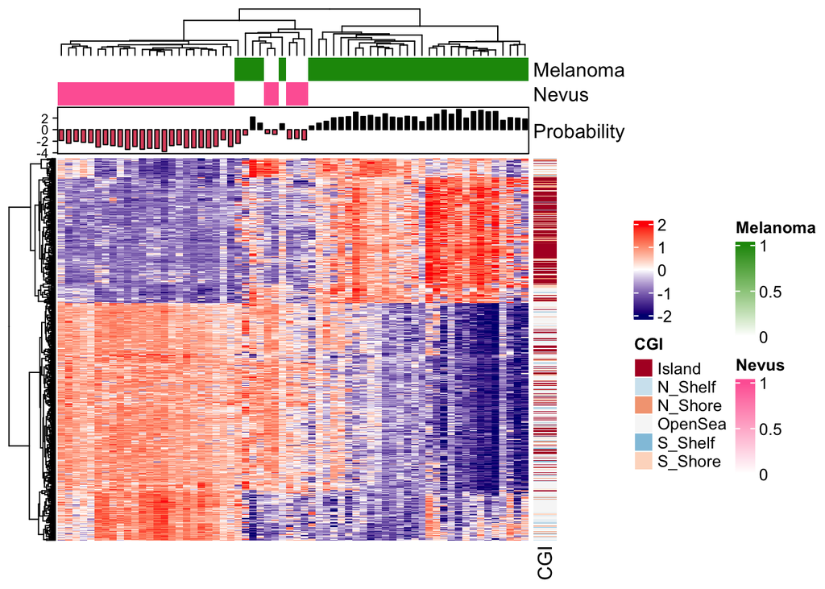

Heatmap of the CpGs selected from the Elastic Net Regression model and those with an absolute correlation value to them of > 0.8 on the independent test dataset. The heatmap is generated on scaled M values. Probability refers to a transformed probability from the model predictions of a sample being Melanoma or Nevus. The probability was conditionally transformed so that its center is 0 and negative numbers were indiciative of prediction of Nevus and positive values a prediction of Melanoma

```r
library(RColorBrewer)
library(ComplexHeatmap)

p_anno_test <- data.frame(Nevus = if_else(test_pheno$Type ==
    "Nevus", 1, 0), Melanoma = if_else(test_pheno$Type == "PrimaryMelanoma",
    1, 0), Probability = as.numeric(glm_preds[, 1]), row.names = rownames(test_mel))

ha <- HeatmapAnnotation(Melanoma = if_else(test_pheno$Type ==
    "PrimaryMelanoma", 1, 0), Nevus = if_else(test_pheno$Type ==
    "Nevus", 1, 0), Probability = anno_barplot(if_else(p_anno_test$Probability <
    0.5, p_anno_test$Probability - 1, p_anno_test$Probability),
    baseline = 0, gp = gpar(fill = if_else(p_anno_test$Probability >
        0.5, 1, 2))))

cols1 <- colorRamp2(c(-2, 0, 2), colors = c("navy", "white",
    "red"))

# scale_test <- scale(test_mel[,colnames(test_mel) %in%
# elas_glm_coefficients$name], scale = T, center = T)

scale_test <- scale(test_mel[, colnames(test_mel) %in% cor_cpgs],
    scale = T, center = T)

glm_cpg_info <- anno[match(colnames(scale_test), anno$Name),
    ]

# glm_cpg_info <-
# elas_glm_coefficients[match(colnames(scale_test),
# elas_glm_coefficients$name),]
glm_cpg_info$CGI <- gsub(";.*", "", glm_cpg_info$Relation_to_Island)

cgi_cols <- brewer.pal(11, "RdBu")
cgi_cols <- cgi_cols[c(2, 4, 5, 7, 8, 6)]
names(cgi_cols) <- c("Island", "N_Shore", "S_Shore", "N_Shelf",
    "S_Shelf", "OpenSea")
ra <- rowAnnotation(CGI = glm_cpg_info$CGI, col = list(CGI = cgi_cols))


Heatmap(t(scale_test), cluster_rows = T, cluster_columns = T,
    clustering_distance_rows = "spearman", clustering_distance_columns = "spearman",
    show_row_names = F, show_column_names = F, top_annotation = ha,
    col = cols1, name = " ", split = c(), right_annotation = ra)
```

```r
# pheatmap(t(test_mel[,colnames(test_mel) %in%
# elas_glm_coefficients$name]), scale = 'row',
# clustering_method = 'ward.D2', clustering_distance_rows =
# 'euclidean', clustering_distance_cols = 'euclidean',
# show_colnames = F, annotation = p_anno_test, fontsize_row
# = 3, breaks = seq(-2,2, length.out = 101),
# annotation_colors = annot_colors)
```